# Exercise #3

Fortgeschrittene Statistische Software für NF

Shuman Mo (12468087)  
2024-06-07

## Exercise 1: Initializing git

### d)

- Strength

**Distributed Version Control**: Git’s distributed architecture allows every user to have a complete copy of the repository, including its full history. This ensures that work can be done offline and reduces the risk of data loss since every user has a full backup.

**Branching and Merging**: Git provides powerful branching and merging capabilities. Branches in Git are lightweight and can be created quickly, allowing users to experiment and develop features in isolation from the main codebase.

- Weaknesses

**Complexity**: Git has a steep learning curve, especially for beginners. Its command-line interface and the complexity of certain commands can be daunting.

**Performance with Large Repositories**: While Git handles small to medium-sized repositories efficiently, it can experience performance issues with very large repositories or repositories with a large number of files and long history.

## Exercise 2: Putting your Repository on GitHub

### a)

https://github.com/MosGalaxy/2024-exeRcise-sheet-3.git

## Exercise 3: Baby-Names in Munich

### b)

```r
# Load data for 2023 and 2022
vornamen_2023 <- read_csv("DATA/vornamen-muenchen-2023.csv")
vornamen_2022 <- read_csv("DATA/open_data_portal_2022.csv")

# Check the type of the "Anzahl" variable for both years
class(vornamen_2023$Anzahl)
```

```
[1] "character"
```

```r
class(vornamen_2022$Anzahl)
```

```
[1] "character"
```

After examining the data, we found that some counts are represented as non-numeric values (e.g., “4 oder weniger”). We can use ifelse to conditionally convert “4 oder weniger” to 4 while keeping other values as numeric.

Compared to converting to NA, this approach retains the sample size and contextual information associated with the “<= 4” values if necessary.

### c)

```r
# Calculate the total number of babies born in Munich in 2023 and 2022
total_babies_2023 <- sum(vornamen_2023$Anzahl)
total_babies_2022 <- sum(vornamen_2022$Anzahl)
```

### d)

```r
# Add a new column 'year' to both datasets
vornamen_2022$year <- 2023
vornamen_2023$year <- 2022

# Print the datasets to verify the changes
head(vornamen_2023)
```

```
# A tibble: 6 × 4
  Vorname    Anzahl Geschlecht  year
  <chr>       <dbl> <chr>      <dbl>
1 Leon          107 m           2022
2 Maximilian    105 m           2022
3 Emilia         89 w           2022
4 Paul           89 m           2022
5 Noah           83 m           2022
6 Anton          80 m           2022
```

```r
head(vornamen_2022)
```

```
# A tibble: 6 × 4
  Vorname Anzahl Geschlecht  year
  <chr>    <dbl> <chr>      <dbl>
1 Emilia     103 w           2023
2 Emma       101 w           2023
3 Mia         93 w           2023
4 Sophia      78 w           2023
5 Anna        72 w           2023
6 Lea         71 w           2023
```

### e)

```r
# Combine both datasets into one
combined_data <- bind_rows(vornamen_2023, vornamen_2022)

# Print the combined dataset
head(combined_data)
```

```
# A tibble: 6 × 4
  Vorname    Anzahl Geschlecht  year
  <chr>       <dbl> <chr>      <dbl>
1 Leon          107 m           2022
2 Maximilian    105 m           2022
3 Emilia         89 w           2022
4 Paul           89 m           2022
5 Noah           83 m           2022
6 Anton          80 m           2022
```

### f)

```r
# Group the data by name and sum the counts
popular_names <- combined_data %>%
  group_by(Vorname) %>%
  summarise(Total_Count = sum(Anzahl)) %>%
  arrange(desc(Total_Count))

# Print out the top 10 names for both years in a nicely formatted table
kable(popular_names[1:10, ], row.names = FALSE, caption = "Top 10 Most Popular Names Across 2022 and 2023")
```

Table 1: Top 10 Most Popular Names Across 2022 and 2023

| Vorname | Total_Count |
| --- | --- |
| Maximilian | 209 |
| Emilia | 192 |
| Leon | 188 |
| Anton | 181 |
| Emma | 172 |
| Felix | 166 |
| Mia | 163 |
| Paul | 161 |
| Noah | 159 |
| Jonas | 158 |

## Exercise 4: Open Analysis

### c)

- Dataset Name: Indicators for “What is PPP?” - World Bank
- Link: https://github.com/owid/owid-datasets/tree/master/datasets/Indicators%20for%20!What%20is%20PPP!%20%20-%20World%20Bank#indicators-for-what-is-ppp----world-bank

### d)

**Research Question**: How does the Price Level Ratio (PLR) affect the discrepancy between GDP per capita (PPP) and GDP per capita (USD) across countries?

**Rationale**: This question explores the impact of cost of living on the perceived economic output per individual, providing insights into economic well-being across different countries.

### e)

```r
# Load the dataset in R
PLR_GDPcp_1990_2015 <- read_csv("DATA/PLR_GDPcp_1990_2015.csv")

# View the data structure
head(PLR_GDPcp_1990_2015)
```

```
# A tibble: 6 × 5
  Entity       Year Price level ratio of PPP …¹ GDP per-capita - PPP…²
  <chr>       <dbl>                       <dbl>                  <dbl>
1 Afghanistan  2002                       0.215                     NA
2 Afghanistan  2003                       0.215                     NA
3 Afghanistan  2004                       0.239                     NA
4 Afghanistan  2005                       0.247                     NA
5 Afghanistan  2006                       0.256                     NA
6 Afghanistan  2007                       0.306                     NA
# ℹ abbreviated names:
#   ¹`Price level ratio of PPP conversion factor (GDP) to market exchange rate (World Bank)`,
#   ²`GDP per-capita - PPP int-$ adjusted (World Bank)`
# ℹ 1 more variable:
#   `GDP per-capita - US $ market exchange (World Bank)` <dbl>
```

```r
# Standardize the column names to snake_case
PLR_GDPcp_1990_2015 <- PLR_GDPcp_1990_2015 %>%
  clean_names()

# Abbreviate the column names
PLR_GDPcp_1990_2015 <- PLR_GDPcp_1990_2015 %>%
  rename(
    plr = price_level_ratio_of_ppp_conversion_factor_gdp_to_market_exchange_rate_world_bank,
    gdp_pc_ppp = gdp_per_capita_ppp_int_adjusted_world_bank,
    gdp_pc_usd = gdp_per_capita_us_market_exchange_world_bank
  )
```

```r
# Check for missing values
summary(PLR_GDPcp_1990_2015)
```

```
    entity               year           plr
 Length:4724        Min.   :1990   Min.   :0.07646
 Class :character   1st Qu.:1996   1st Qu.:0.32337
 Mode  :character   Median :2003   Median :0.45913
                    Mean   :2003   Mean   :0.53654
                    3rd Qu.:2009   3rd Qu.:0.65366
                    Max.   :2015   Max.   :1.85511
                                   NA's   :3
   gdp_pc_ppp         gdp_pc_usd
 Min.   :   618.8   Min.   :   277.1
 1st Qu.:  3918.5   1st Qu.:  1833.2
 Median : 11479.1   Median :  4960.5
 Mean   : 19465.2   Mean   : 12947.1
 3rd Qu.: 26659.9   3rd Qu.: 15452.7
 Max.   :141542.7   Max.   :101450.0
 NA's   :4541       NA's   :4541
```

```r
# Remove rows with missing values
PLR_GDPcp_2015 <- na.omit(PLR_GDPcp_1990_2015)
```

```r
# Filter out rows where price level ratio is greater than 1
higher_lc_2015 <- PLR_GDPcp_2015 %>%
  filter(plr > 1)

print(higher_lc_2015) # Countries of higher living costs in 2015
```

```
# A tibble: 9 × 5
  entity          year   plr gdp_pc_ppp gdp_pc_usd
  <chr>          <dbl> <dbl>      <dbl>      <dbl>
1 Australia       2015  1.22     46271.     56311.
2 Denmark         2015  1.08     48009.     51989.
3 Finland         2015  1.00     42236.     42311.
4 Iceland         2015  1.06     47202.     50173.
5 New Zealand     2015  1.01     37576.     37808.
6 Norway          2015  1.20     62084.     74400.
7 Sweden          2015  1.06     47855.     50580.
8 Switzerland     2015  1.29     62557.     80945.
9 United Kingdom  2015  1.05     41756.     43876.
```

The table indicates that goods and services were relatively more expensive in these countries compared to the United States back in 2015.

However, this does not directly imply a higher inflation rate of the year. To examine if there was a higher inflation rate, we need to take a closer look at the differences between GDP per capita (PPP) and GDP per capita (USD).

```r
# Compute the difference between GDP per capita (PPP) and GDP per capita (USD)
PLR_GDPcp_2015 <- PLR_GDPcp_2015 %>%
  mutate(gdp_diff = gdp_pc_ppp - gdp_pc_usd)

high_inflated_2015 <- PLR_GDPcp_2015 %>%
  filter(gdp_diff < 0)

print(high_inflated_2015)
```

```
# A tibble: 9 × 6
  entity          year   plr gdp_pc_ppp gdp_pc_usd gdp_diff
  <chr>          <dbl> <dbl>      <dbl>      <dbl>    <dbl>
1 Australia       2015  1.22     46271.     56311. -10040.
2 Denmark         2015  1.08     48009.     51989.  -3980.
3 Finland         2015  1.00     42236.     42311.    -74.8
4 Iceland         2015  1.06     47202.     50173.  -2971.
5 New Zealand     2015  1.01     37576.     37808.   -232.
6 Norway          2015  1.20     62084.     74400. -12317.
7 Sweden          2015  1.06     47855.     50580.  -2725.
8 Switzerland     2015  1.29     62557.     80945. -18388.
9 United Kingdom  2015  1.05     41756.     43876.  -2120.
```

The table shows these countries experienced a high inflation back in 2015.

```r
# Calculate correlation
correlation <- cor(higher_lc_2015$plr, high_inflated_2015$gdp_diff)

# Print correlation
print(correlation)
```

```
[1] -0.9859214
```

### f)

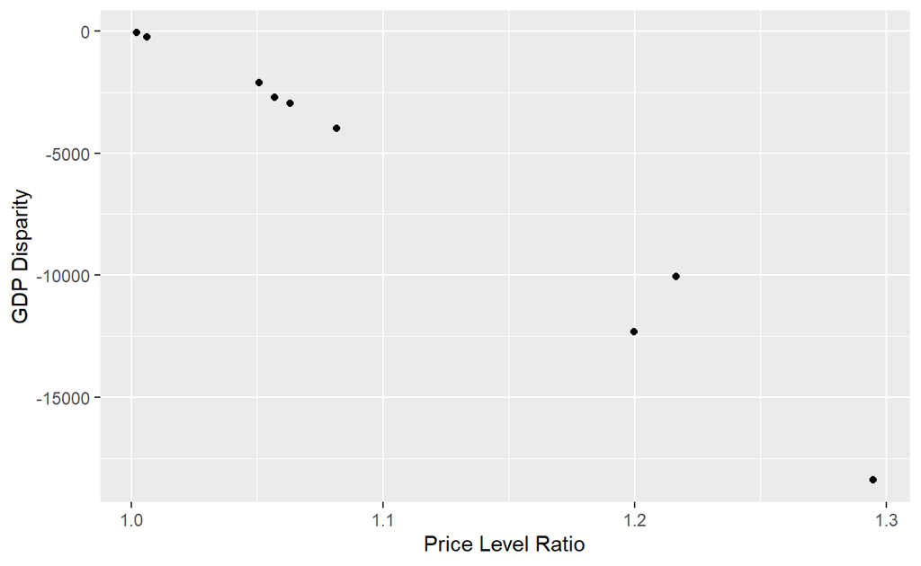

Figure 1: Relationship between Price Level Ratio and GDP Disparity

```r
# Create a scatter plots
ggplot(high_inflated_2015, aes(x = plr, y = gdp_diff)) +
  geom_point() +
  labs(x = "Price Level Ratio", y = "GDP Disparity")
```